# Randomization, Bootstraping, and Monte Carlo Methods

2026-04-14

Randomization tests are useful because they do not assume **any** underlying distribution.

# Basic built-in Functionality

Sampling from distributions can be useful.

```r
# sample normal distribution
rand.norm = rnorm(n = 10, mean = 0, sd = 1)
```

## Sampling Distributions

To ensure its a normal distribution, we can increase our sample size (Central Limit Theorem)

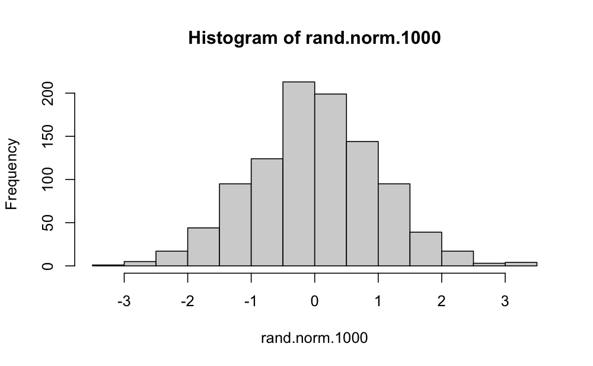

```r
rand.norm.1000 = rnorm(n = 1000, mean = 0, sd = 1)
hist(rand.norm.1000)
```

We can also sample other distributions. The uniform distribution is helpful when we want to sample values in a range with each value being equally likely.

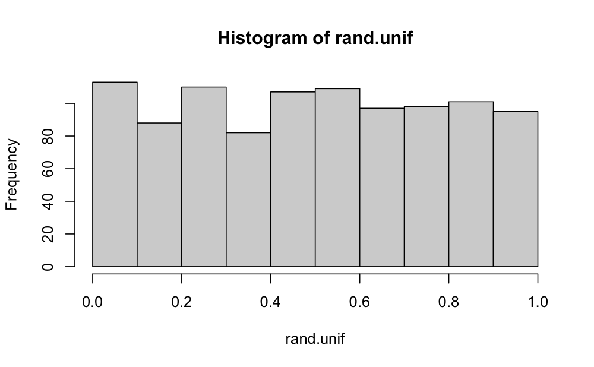

```r
rand.unif = runif(n = 1000, min = 0, max = 1)
hist(rand.unif)
```

Bars are similar heights due to a similar frequency of each being sampled. Thus, each value in the range has an *equal chance* of being selected.

A **Poisson Distriubtion** is very helpful in biology because many processes can be fit with the ‘count data’ distribution of a Poisson.  
A poisson process describes events happening with some probability over space or time. Lambda is both the mean and variance of the distribution.

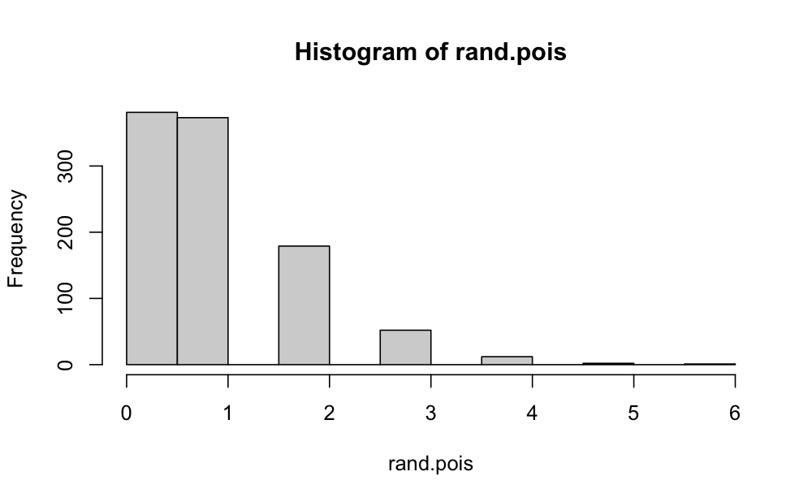

```r
rand.pois = rpois(n = 1000, lambda = 1)
hist(rand.pois)
```

## Sampling from a Vector

Often, you want to be able to sample from a prescribed set of values (a vector).

```r
# sample a vector
rand.numb.1 = sample(x = 1:10, size = 1) |> print()
```

```
[1] 8
```

We can also define the vector first, and then sample from it.

```r
x = c(1:10)
z = sample(x, size = 10) |> print()
```

```
 [1]  1 10  4  9  7  5  2  3  8  6
```

We can also define replacement (values reinputted to vector if previously sampled) or not. The default in sample is `replace = F`.

```r
# sample vector with replacement
rand.numb.r = sample(x, 10, replace = T) |> print()
```

```
 [1]  5 10  5  5  1  8  3  9  5  5
```

## Weighted Sampling

If certain values are more probable than others within the vector, we can specify the exact probability of each value in the vector. This requires a *probability vector*

```r
# establish a probability vector
prob.vec = c(rep(x = 0.05, times = 5), rep(x = 0.15, times = 5)) |> print()
```

```
 [1] 0.05 0.05 0.05 0.05 0.05 0.15 0.15 0.15 0.15 0.15
```

```r
sum(prob.vec) |> print()
```

```
[1] 1
```

Now we bias our sampling based off of this probability vector. Each value in the probability vector lines up to its coresponding value in the sample vector’s position.

```r
# weighted sampling
rand.numb.bias = sample(x, size = 10, replace = T, prob = prob.vec) |> print()
```

```
 [1]  5  2 10  4  6  9  1  9  5  9
```

# Randomization for Hypothesis Testing

```r
birds = read.csv("Bumpus_data.csv")
```

```r
bird.t.test = t.test(birds$wgt ~ birds$surv, alternative = "less") |> print()
```

```
    Welch Two Sample t-test

data:  birds$wgt by birds$surv
t = -2.5161, df = 117.88, p-value = 0.006605
alternative hypothesis: true difference in means between group alive and group dead is less than 0
95 percent confidence interval:
       -Inf -0.2164464
sample estimates:
mean in group alive  mean in group dead
           25.22639            25.86094
```

Our dataset is large enough that we do **not** have to be concerned with violating the assumptions of a t-test. However, this may not always be the case.

With resampling/randomization test, we are able to relax assumptions of a t-test (particularly useful in small sample sizes).  
Randomization allows us to build a probability distrubition by continually resampling **our** dataset, and finding out how likely our **initial** finding is given this probability distribution.

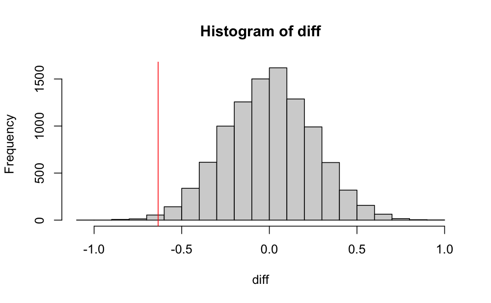

```r
iter <- 9999;  # This is the amount of iterations/runs we want
diff <- NULL;  # A vector to store differences between groups in each iteration
N_birds <- dim(birds)[1] # Total number of birds

for(i in 1:iter){
  bird_samp <- sample(x = birds$surv, size = N_birds, replace = F)
  samp_alive <- which(bird_samp == "alive")
  samp_dead <- which(bird_samp == "dead")
  mu_samp_A <- mean(birds[samp_alive, 5])
  mu_samp_D <- mean(birds[samp_dead, 5])
  diff[i] <- mu_samp_A - mu_samp_D
}

tru_w_A <- mean(birds[birds$surv == "alive", 5])
tru_w_D <- mean(birds[birds$surv == "dead", 5])
td <- tru_w_A - tru_w_D
hist(diff)
abline(v = td, col = "red")
```

The randomization generates a **Null** distribution of differences in body weights. Our distribution assumes that there is **no association** of body weight and survival status.

Now we can find the likelihood of observing our true value given this null distribution.

```r
less_equal_to <- diff[diff <= td] # values less than or equal to observed
(length(less_equal_to)+1)/(length(diff)+1) # proportion of these values to the total
```

```
[1] 0.0049
```

```r
# we add 1 due to our observed value being included
```

## Spatial Randomization

```r
fpet <- read.csv("FpetTrees.csv")
```

```r
lat1 = 28.289
lat2 = 28.2918
lon1 = -113.1145
lon2 = -113.1095

plot(x = fpet[,4], y = fpet[,3], xlab = "Longitude", ylab = "Latitude",
     pch = 20, cex.lab = 1.25, cex.axis = 1.25,
     xlim = c(lon1, lon1-0.001, lon2 + 0.001),
     ylim = c(lat1 - 0.0005, lat2 +0.0005))
```

[output not shown]

## Randomization for Relationshiops

Correlations and regressions assume a normal distribution and a linear relationship.  
This may not always be the case for our data.

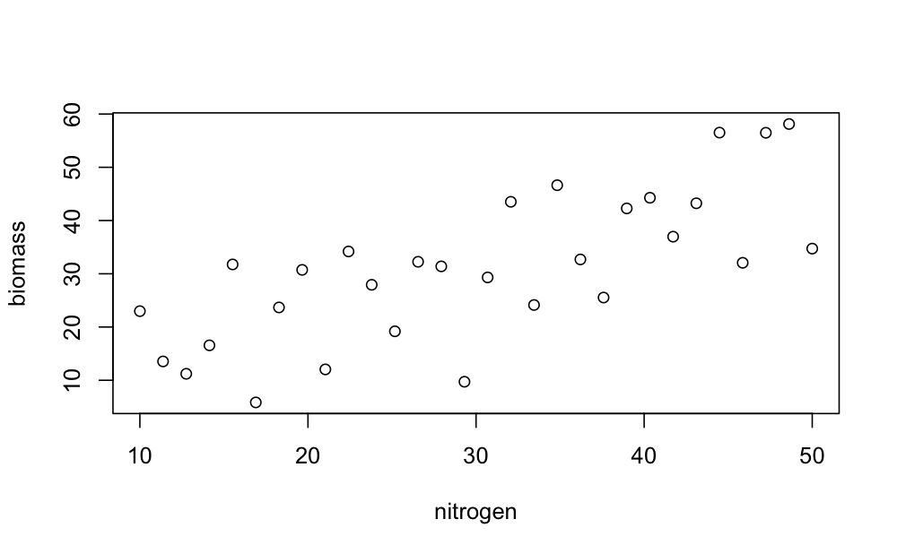

First let’s look at the actual correlation between our variables.

```r
obs_r = cor(nitrogen, biomass) |> print()
```

```
[1] 0.4991999
```

A correlation works well with tight fitted data, but there are often outliers in true observed data, especially in ecology.

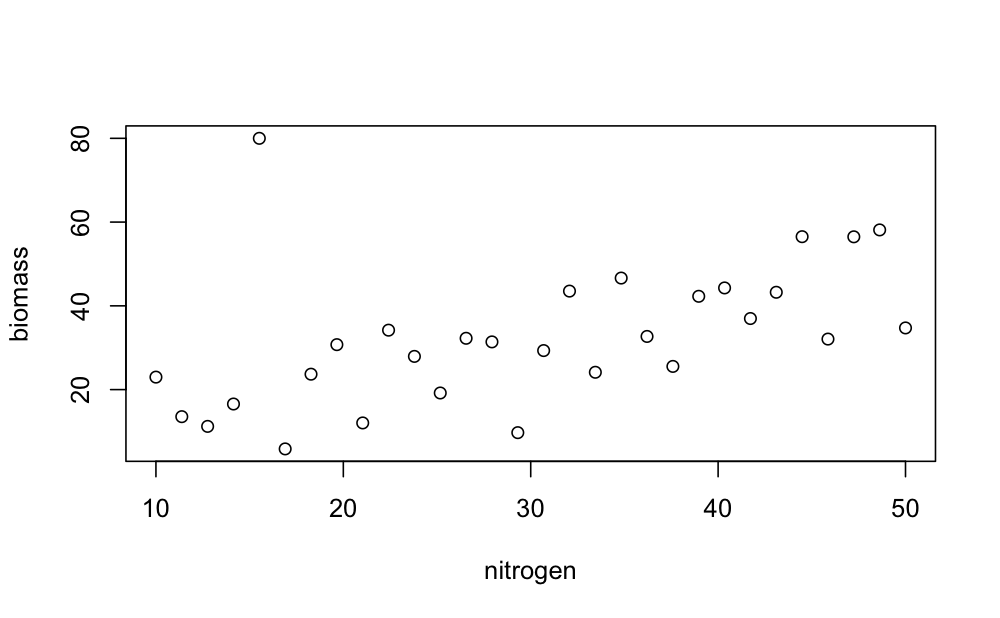

```r
biomass[5] <- 80
plot(biomass~nitrogen)
```

Removing outliers to deal with their influence can remove true variation in the data that we are interested in. This is where randomization comes in.  
Randomization allows us to incorporate all of the data, even egregious outliers.

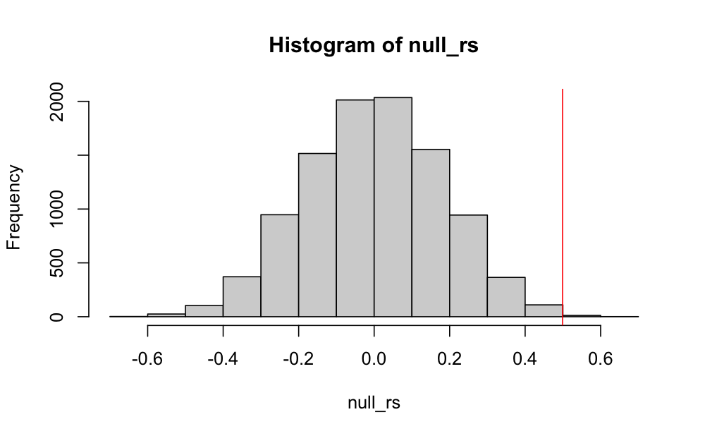

```r
reps = 9999
null_rs <- numeric(reps)
N_biomass <- length(biomass)

for(i in seq_len(reps)){
  # First, we shuffle the variables to break apart any actual relationship
  shuffled_biomass <- sample(biomass, size = N_biomass, replace = F)

  # Now we calculate the correlation coefficient for this run
  null_rs[i] <- cor(nitrogen, shuffled_biomass)
}

hist(null_rs)
abline(v = obs_r, col = "red")
```

We can see that our observed correlation coefficient (the red line) is well outside the 95% confidence interval.

```r
p.value <- (sum(abs(null_rs) >= abs(obs_r)) / (reps + 1)) |> print()
```

```
[1] 0.004
```

**The Outlier Problem:**  
Standard correlation tests are very sensitive to outliers. Randomization tests are based on the actual distribution of your specific data, making them less likely to give a “false significance” (type I error) driven by a *single* datapoint.

## Avoidance/Co-occurence Tests

We have present (1) and absent (0) data. We want to test if two species show up together more than we would expect due to chance. Do they prefer to cohabitate?

```r
# 50 plots
n_plots <- 50

# Generate random occurrence data for both species
woodpecker <- rbinom(n_plots, 1, 0.4) # assign "1" with "40%" probability
nuthatch <- rbinom(n_plots, 1, 0.4)

# Force a few extra aco-occurrences to simulate a relationshjip
woodpecker[1:10] <- 1
nuthatch[1:10] <- 1

site_mat <- matrix(woodpecker, nuthatch)
```

Now we set up our test statistic we will use, and we calculate it for our *true* observed value.

```r
obs_cooccur <- sum(site_mat$woodpecker == 1 & site_mat$nuthatch == 1) |> print()
```

[output not shown]

This is simply the number of sites the two species co-occur in.  
Now we set up our randomization test/model.

```r
reps <- 9999
null_counts <- numeric(reps)

for(i in seq_len(reps)){
  # shuffle the nuthatch sites
  shuffled_nuthatch <- sample(site_mat$nuthatch)

  #shuffle the woodpecker sites
  shuffled_woodpecker <- sample(site_mat$woodpecker)

  # calculate frequency of co-occurrence
  null_counts[i] <- sum(shuffled_woodpecker == 1 & shuffled_nuthatch == 1)
}
```

Now we can make a *pretty* plot.

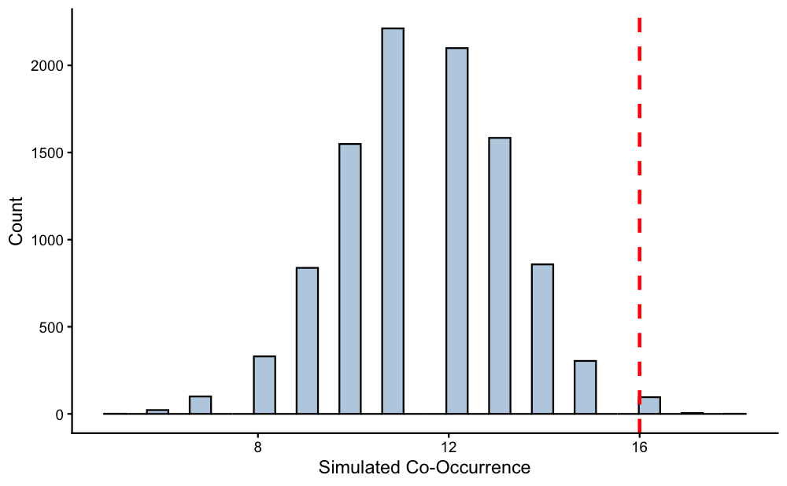

Now we calculate our p-value for co-occurrence:

```r
p.value <- (sum(null_counts >= obs_cooccur)/(reps + 1)) |> print()
```

```
[1] 0.0102
```

**Chi-Squared Limitations:**  
In ecology, some species are naturally rare and others can be very *common*. The standard use of a Chi-squared test can be invalid when species are common in general. By shuffling our locations but keeping the total count fixed, you account for the fact that a common species is likely to overlap with others just by being everywhere.

## ANOVA-design Randomization (>2 groups)

A one-way ANOVA is very useful for comparing groups. However, ecological data–such as frequency of species occurrence–is often *count* data, and thus does not follow a normal distribution, but a *Poisson* distribution. The 0’s in a Poisson violate the assumptions of an ANOVA.  
**The example:**  
We want to test three different methods to restore native prairie: controlled burning, conservation grazing, and mowing (control). We measured the density of native grass stems per square meter in 15 plots for each treatment (45 plots total).  
a **Randomization ANOVA** allows us to test for differences accross mulitple groups without worrying about whether your residuals are perfectly bell-shaped.

| stems | treatment |
| --- | --- |
| 28 | Burn |
| 27 | Burn |
| 23 | Burn |
| 21 | Burn |
| 19 | Burn |
| 33 | Burn |
| 23 | Burn |
| 31 | Burn |
| 17 | Burn |
| 27 | Burn |

[output cut: 35 more lines]

Now we have all of our grass data for the three treatments in one dataframe.  
Now, we decide on, and calculate our test statistic. Since it is an ANOVA design, we will use the **F statistic**.

```r
obs_anova[[1]]
```

```
            Df Sum Sq Mean Sq F value   Pr(>F)
treatment    2  821.2  410.60  20.346 6.63e-07 ***
Residuals   42  847.6   20.18
---
Signif. codes:  0 ‘***’ 0.001 ‘**’ 0.01 ‘*’ 0.05 ‘.’ 0.1 ‘ ’ 1
```

Now we can randomize our data and simulate a distribution of F statistics. To do this, we can simply shuffle **group membership** instead of the dependent variable data itself. This shuffles the assignment just the same.

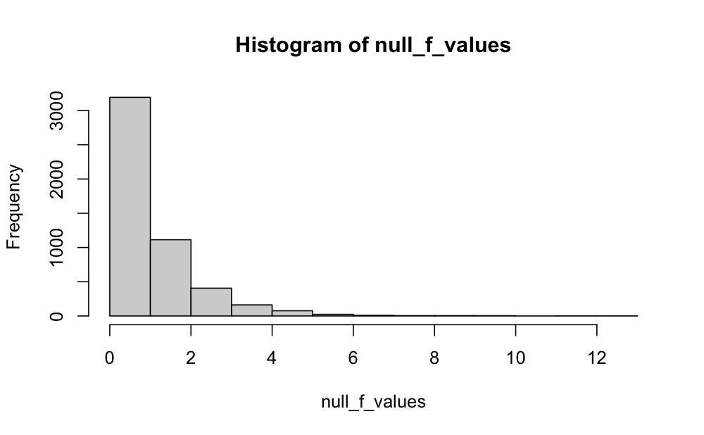

```r
reps <- 4999
null_f_values <- numeric(reps)

for(i in seq_len(reps)){
  # Shuffle treatment
  shuffled_labeels <- sample(restoration_data$treatment) # NO replacement

  # Run ANOVA on the shuffled data and grab the F values
  s_anova <- summary(aov(restoration_data$stems ~ shuffled_labeels))
  null_f_values[i] <- s_anova[[1]]["shuffled_labeels", "F value"]
}

hist(null_f_values)
abline(v = obs_F, col = "red")
```

Notice that our line for our observed value is not on the histrogram, that is because it is so much larger than what was simulated with our randomization.

Now we can calculate the p-value:

```r
p.value = (sum(null_f_values >= obs_F)/ (reps + 1)) |> print()
```

```
[1] 0
```